# Research Method of Data Science

## Week 12: Regression as a Research Method

### Iegor Vyshnevskyi, Ph.D.

### Sogang University

### November 17/19, 2026

# Week 12: Regression as a research method

**Tuesday:** specification, interpretation and evidence

**Thursday:** a guided regression and prediction lab

Regression is useful only when the specification, evidence, and claim all answer the same research question.

# Agenda

**Tuesday - Meeting 1**

1. Turn a research question into a regression comparison

2. Understand what changes when controls are added

3. Check patterns the model did not explain

4. Compare prediction methods on new records

5. Connect the lesson to your own project

Appendix: optional advanced models and software references.

The lesson starts with a question, builds a model, checks its weaknesses, and then asks whether it predicts new cases well.

# What do we want a model to answer?

**Question A:** How is vehicle weight associated with fuel economy, accounting for recorded characteristics?

**Question B:** How accurately can those characteristics predict fuel economy for similar records?

**Think, then discuss with a neighbour:** What evidence would count as success for each question?

**Explanatory aim:** interpret a defined comparison. **Predictive aim:** estimate outcomes accurately for similar unseen records.

# 1. From a research question to a regression line

We begin with the outcome and comparison, then use OLS to draw the straight line that best summarizes the observed pattern.

# One real dataset, two research aims

**Auto MPG:** 398 historical vehicle records, model years 1970–1982.

| Variable | Meaning |
|---|---|
| MPG | City-cycle miles per gallon |
| Weight | Pounds, divided by 1,000 in our OLS model |
| Horsepower | Engine characteristic, six values missing |
| Model year and origin | Time code and categorical origin code |

Source: UCI Auto MPG, DOI **10.24432/C5859H**, CC BY 4.0.

**Reading the outcome:** higher MPG means a vehicle travels farther per gallon and therefore has better measured fuel economy.

# Where the 398 vehicles go

**398 vehicles**Full historical dataset

## 298 training vehicles

We use these records to **build, inspect, and choose** models.

**Why does OLS use 294?**  
Four training vehicles have no horsepower value, so the explanatory OLS examples leave them out.

**Prediction models use all 298.**  
They fill missing horsepower using information learned from training data.

## 100 test vehicles

We keep these records aside while developing the models.

We use them **once at the end** to check prediction on unseen records.

**Why split the data?** The untouched test set gives a more honest check of how the chosen model predicts new records.

# OLS draws the best-fitting straight line

**Question:** how does average MPG differ as vehicle weight changes?

**OLS** stands for *ordinary least squares*. It chooses the straight line that makes the overall prediction mistakes as small as possible.

## Fitted value

The MPG predicted by the line for one vehicle.

## Residual

Actual MPG minus predicted MPG. It is the vertical gap from a point to the line.

**Weight unit:** the model records weight in 1,000 lb, so a change of 0.5 means 500 lb.

# The fitted line summarizes a real pattern

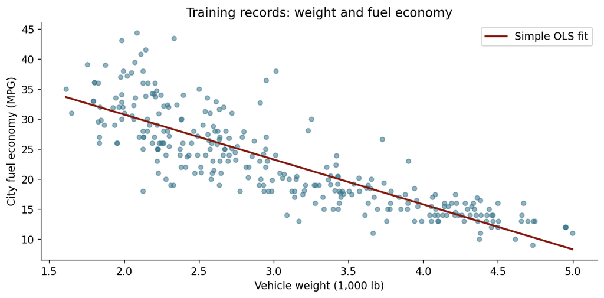

**How to read:** move 1 unit right for 1,000 additional pounds; the fitted line falls by about 7.48 MPG in the simple model.

# Interpretation challenge — pairs, 4 minutes

The simple slope is about **−7.48 MPG per 1,000 lb**.

1. Interpret a **500 lb** difference in vehicle weight.

2. Explain why “every heavier car has worse MPG” overstates the model.

3. Can we claim that removing 500 lb causes this change?

Prepare one careful sentence.

Convert the coefficient to the requested change: 500 lb is half of the model's 1,000 lb weight unit.

# 2. Adding controls and measuring uncertainty

Adding variables changes the comparison. Confidence intervals show how precisely the adjusted comparison is estimated.

# Adding controls changes the question

**Simple model:** compare MPG across vehicle weights.

**Adjusted model:** compare vehicle weights while also accounting for recorded horsepower, model year, and origin.

## What “holding fixed” means

The model compares vehicles at the same recorded values of the included controls.

## What it does not mean

The vehicles are not identical, and adding controls does not automatically create a causal comparison.

The technical name for the chosen variables and equation is the **model specification**.

# A regression table should support interpretation

| Term | Estimate | HC3 SE | t | p | 95% CI |
|---|---:|---:|---:|---:|---:|
| Weight / 1,000 lb | -5.613 | 0.488 | -11.50 | < .001 | [-6.574, -4.653] |
| Horsepower | -0.005 | 0.010 | -0.50 | .617 | [-0.026, 0.015] |
| Model year | 0.755 | 0.057 | 13.25 | < .001 | [0.642, 0.868] |

Outcome: **MPG**. N = **294**. Adjusted training R² = **0.827**.

### Weight

Holding horsepower, model year, and origin fixed, a vehicle that is **1,000 lb heavier** is associated with **5.61 fewer MPG**.

The interval suggests about **4.65 to 6.57 fewer MPG**.

### Horsepower

One additional horsepower is associated with only **0.005 fewer MPG** after adjustment.

The interval crosses zero and p = .617, so this model gives **weak evidence of a separate horsepower association**.

### Model year

Holding the other variables fixed, one later model year is associated with **0.76 higher MPG**.

The interval suggests about **0.64 to 0.87 higher MPG**.

Origin indicators and the intercept are included but not displayed. HC3 SE is Heteroskedasticity-Consistent Standard Error used for uncertainty. These are adjusted associations, not automatically causal effects.

# Adjusted estimates at a glance

[figure not shown]

Dots are adjusted estimates. Horizontal lines are approximate 95% HC3 confidence intervals. The dashed line marks no fitted MPG difference.

**Read the zero line:** the horsepower interval crosses zero; the weight and model-year intervals do not. Position shows direction, while interval width shows precision.

# Adjustment changes the interpretation

[figure not shown]

Both estimates use the same 294 records. The adjusted model also includes horsepower, model year, and origin.

The adjusted association is less negative because it answers a different comparison. This change does not reveal how much causal bias was removed without additional assumptions.

The simple and adjusted slopes differ because they summarize different comparisons, not because one coefficient is automatically the truth.

# Uncertainty and fit answer different questions

**Coefficient interval:** how uncertain is the estimated conditional slope under the model?

**R²:** how much training variation does the fitted model account for?

**Prediction error:** for vehicles that were **not used to build the model**, compare the predicted MPG with the actual MPG.

**Example:** the model predicts 28 MPG, but the vehicle actually has 25 MPG. The prediction misses by **3 MPG**.

A high R² cannot validate the causal interpretation or guarantee useful predictions.

**“Held out” means kept aside.** The 100 test vehicles were not used to choose or fit the model. Smaller prediction errors on these records indicate better prediction for similar unseen vehicles.

# Table challenge — pairs, 4 minutes

Using the adjusted table:

1. Write a sentence for a **500 lb** weight contrast.
2. Does the horsepower interval establish “no relationship”?
3. What does R² = 0.827 tell us? What remains unanswered?

Include the sample and the word **associated** in your answer.

A confidence interval containing zero signals limited precision for that coefficient; it does not prove that the relationship is exactly zero.

# 3. Checking model problems and research limits

Model checks show patterns left unexplained. Research design determines whether the final claim is descriptive, associational, predictive, or causal.

# Model checks ask what the regression missed

| Check | Plain-language question |
|---|---|
| Residuals versus predictions | Do the mistakes form a pattern instead of a random cloud? |
| Q-Q plot of residuals | Are there unusually large mistakes in the tails? |
| Unusual predictor values (leverage) | Is a vehicle far from most others in its recorded characteristics? |
| Influence (Cook's distance) | Does one vehicle noticeably change the fitted model? |
| Data and design documentation | Could selection, missing data, or related records affect the claim? |

A warning sign tells us what to investigate. No single graph gives the entire regression a pass or fail.

# A curved line can describe the pattern better

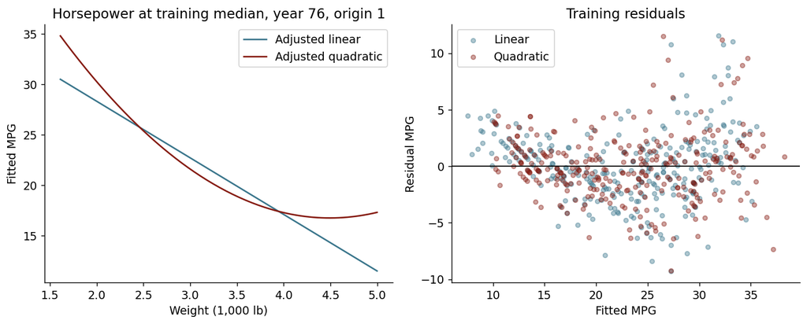

### Left: fitted MPG

The straight line assumes the same weight-MPG change everywhere. The curved line allows the pattern to flatten or bend for lighter and heavier vehicles.

### Right: prediction mistakes

A good residual plot looks like a loose cloud around zero. A visible curve means the model is still missing a systematic pattern.

**Interpretation:** the curved model follows the training pattern better, but this alone does not prove a causal effect or guarantee good prediction for new vehicles.

# A curved model has no single weight effect

## Straight-line model

Uses one weight slope for every vehicle. An additional 1,000 lb has the same fitted MPG difference across the entire graph.

## Curved model

The fitted MPG difference depends on the starting weight. We therefore report the slope at a specific weight.

**Near 3,000 lb:** an additional 1,000 lb is associated with about **6.50 fewer MPG**, after accounting for horsepower, model year, and origin.

**“Local slope” means near that weight.** It should not be presented as one universal effect for every light and heavy vehicle.

# HC3 gives safer uncertainty when the scatter is uneven

Regression mistakes may be tightly grouped for some vehicles and widely spread for others. Ordinary standard errors can then be too optimistic.

## What stays the same

The coefficient estimates and the fitted regression line or curve.

## What HC3 recalculates

Standard errors, confidence intervals, t-statistics, and p-values.

**HC3 cannot fix the research design.** It does not solve missing important variables, reverse causality, related observations, or the wrong curve.

Think of HC3 as a more cautious way to report uncertainty when the residual plot has uneven spread.

# Regression can mislead for reasons beyond the equation

| Possible problem | Why it matters |
|---|---|
| Important factor is missing | Weight may stand in for another vehicle characteristic that also affects MPG |
| Measurement is imperfect | Recorded horsepower or MPG may not fully represent the concept of interest |
| Available records are selected | Historical vehicles may differ from modern vehicles or the population we want to discuss |
| Some records are related | Similar models from one manufacturer may not provide fully independent evidence |
| The line has the wrong shape | A straight line may hide curvature or other patterns |

Better software cannot remove these problems automatically. Researchers must use subject knowledge, documentation, and careful claims.

# Which vehicle strongly affects the fitted model?

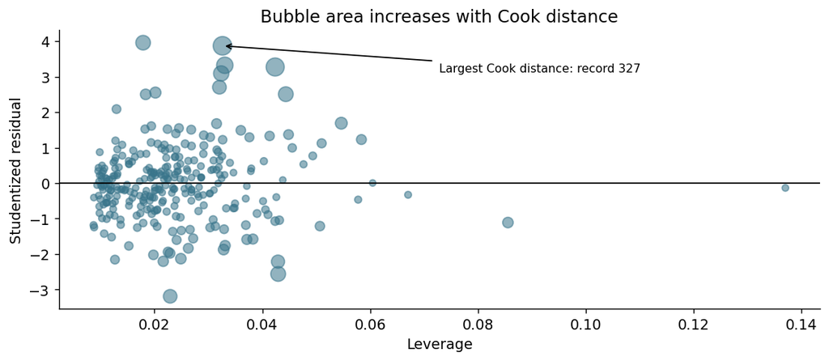

Which record should we investigate? What would justify a correction or exclusion?

### Farther right

The vehicle has an unusual combination of recorded predictors. This is called **high leverage**.

### Larger bubble

The vehicle changes the fitted model more strongly. Bubble size represents **Cook's distance**.

Investigate the original record and context. An influential vehicle can be valid evidence that the model is too simple.

# A sensitivity check asks whether one record drives the result

At 3,000 lb, the curved model gives:

| Analysis | Estimated local slope |
|---|---:|
| Use all 294 training vehicles | -6.50 MPG per 1,000 lb |
| Temporarily leave out the most influential vehicle | -6.59 MPG per 1,000 lb |

The estimate changes very little, so this one vehicle does not drive the result.

This answers one narrow question about sensitivity to one record. It does not prove that the model, sample, or causal interpretation is correct.

# 4. Predicting new vehicles

Prediction asks how close the model comes to actual MPG for vehicles that were not used to build or tune it.

# A model can learn the training data too closely

Weight, engine size, cylinder count, and horsepower are related.

Adding many squared terms and combinations makes the model more flexible. It can then learn small quirks of the training records instead of a pattern that repeats.

**Overfitting:** very good performance on the training data but weaker prediction for new records.

**Regularization** is a method that limits extreme complexity so predictions can be more stable.

# Regression models answer different prediction needs

### Linear OLS

**Fits one straight relationship.**  
Use it when a straight-line summary is reasonable and interpretation matters.

### Polynomial regression

**Allows a curve.**  
Use it when the outcome changes differently at low and high predictor values.

### Ridge regression

**Keeps all predictors but reduces extreme coefficients.**  
Useful when predictors overlap, such as weight, cylinders, and engine size.

### Lasso regression

**Can reduce some coefficients to zero.**  
Useful when we want a smaller prediction formula from many possible features.

**In this lecture:** OLS supports interpretation. Polynomial OLS checks curvature. Ridge and Lasso focus on prediction for new vehicles.

# How Ridge and Lasso control complexity

| Method | Plain-language idea | What students should remember |
|---|---|---|
| OLS | Fits the training data without a penalty | Clear baseline, but flexible versions may overfit |
| Ridge | Pulls large coefficients toward zero | Often stabilizes prediction when predictors overlap |
| Lasso | Pulls coefficients toward zero and can set some exactly to zero | Produces a simpler selected set of features |

Ridge and Lasso need predictors on comparable scales. Their selected coefficients support prediction, not automatic causal importance.

# Choose the model without looking at the final test answers

Keep 100 test vehicles aside.

Use only the training vehicles to compare settings through repeated train-and-check splits. This is cross-validation.

Choose one model and fit it using all training vehicles.

Open the test set once for the final prediction check.

All data preparation must be learned separately inside each training split. This prevents **data leakage**, where the model indirectly sees validation answers.

# Training-data checks choose how strongly Lasso simplifies

[figure not shown]

### Each dot is one choice

Moving right tells Lasso to simplify the model more strongly by shrinking more coefficients.

### Lower means better prediction

For each choice, we repeatedly train on part of the training sample and check predictions on the remaining part.

**Decision:** choose the dot with the lowest average error, then refit Lasso using all 298 training vehicles. The 100 test vehicles remain untouched until the final check.

# Training checks versus the final test

[figure not shown]

### Blue bars: training checks

Each model repeatedly predicts records temporarily set aside from the 298 training vehicles. We use these results to compare models.

### Red bars: final test

After all choices are fixed, each model predicts the 100 vehicles kept separate from the beginning.

**Conclusion:** Ridge and Lasso both have test error near **3.03 MPG**. Their almost identical bars do not support claiming that one is clearly better. Both predict much better than simply using the average MPG.

# 5. Connect regression to your project

Choose a method only after defining your outcome, unit of observation, research aim, and main limitation.

# Different questions need different evidence

| Your aim | Evidence to report |
|---|---|
| Describe an adjusted association | Coefficient or predicted contrast, interval, and model checks |
| Predict new cases | Training/test plan, a simple baseline, prediction errors, and limitations |
| Explain a cause | A credible reason why groups differ in X but not in other causes, plus estimation and uncertainty |
| Understand experiences or meanings | Themes, supporting evidence, interpretation, and trustworthiness |

More controls, more equations, or a higher R-squared do not automatically make a causal claim credible.

# Your project specification clinic — 5 minutes

Write individually for **2 minutes**, then discuss in pairs for **3 minutes**:

- My outcome and unit of observation are ...

- My predictors or alternative evidence follow from ...

- My main claim is descriptive / associational / causal / predictive because ...

- My most serious threat is ...

- One check I can complete is ...

Keep the revised note for your Methods section.

The goal is a coherent chain: question, variables, unit, method, evidence, and limitation should fit together.

# Next class: a guided regression lab

**Open:** `W12_RMDS_Regression_Lab.ipynb`

Save a personal copy in Colab or JupyterLab. The real data are embedded.

You will interpret OLS, inspect residuals, investigate influence, and compare prediction pipelines.

Bring your research question, literature-based variables, and data documentation.

Optional models are clearly marked outside the 75-minute core.

The notebook supplies the code structure; students are responsible for reading outputs, checking assumptions, and writing bounded interpretations.

# Thursday: Regression lab

The lab follows one analysis from source documentation to interpretation, diagnostics, prediction, and reproducible saving.

# Agenda

**Thursday — Meeting 2**

1. Source, split and checks

2. Simple and adjusted OLS

3. Functional form and residuals

4. Influence and robustness

5. OLS, Ridge and Lasso pipelines

6. Test comparison

7. Project note and save

The lab preserves the order of a defensible workflow: document, estimate, diagnose, validate, interpret, and save.

# 1. Source, split and checks — 8 minutes

Run notebook **0–1**.

Confirm **398 source rows**, **298 training rows**, **100 reserved test rows**, and **294 complete OLS training rows**.

Locate the source, missing-value count, measurement units, and origin codes.

**Checkpoint:** Why do OLS and prediction use different training-row counts?

Confirm the sample flow before modelling so every later estimate and error metric has a clear denominator.

# 2. OLS interpretation — 12 minutes

Run notebook **2**.

Read the simple fit and adjusted coefficient table.

Write a sentence for the **500 lb adjusted weight contrast**, with uncertainty and controls.

**Pair check:** Underline the outcome unit, comparison, and claim boundary. Compare your sentence with the simple-model interpretation.

A complete coefficient sentence names the outcome, comparison size, controls, uncertainty, sample, and associational claim boundary.

# 3. Check the curve and prediction mistakes - 12 minutes

Run notebook **3**.

Compare the straight and curved fitted lines, then inspect the residual plots.

1. Describe one remaining visual pattern in plain language.

2. Explain the fitted weight-MPG relationship near **3,000 lb**.

3. State what HC3 changes and one research problem it cannot fix.

Compare your observations with a neighbour.

A residual is actual MPG minus predicted MPG. Look for a random cloud around zero rather than a curve or widening funnel.

# 4. Investigate an influential vehicle - 10 minutes

Run notebook **4**.

Find the vehicle with the largest Cook's distance and inspect its original values and name.

Compare the estimate using all records with the estimate after temporarily leaving out this one vehicle.

**Write:** “This check tells us ... It cannot prove ...”

Keep a valid unusual record in the main analysis unless source evidence supports a correction.

The goal is not to remove inconvenient data. The goal is to understand why a record matters and whether the conclusion depends on it.

# 5. Compare prediction methods - 18 minutes

Run notebook **5**.

Use training cross-validation to compare the mean baseline, OLS, Ridge, and Lasso.

Before opening the test results, record:

- which model has the lowest training cross-validation error

- the Lasso penalty setting and number of retained features

- where missing values and scaling are learned

Explain why a retained Lasso feature is useful for prediction but not proof of causality.

The notebook uses a **pipeline**: an ordered set of preparation and modelling steps repeated correctly inside each training split.

# 6. The fixed test comparison — 7 minutes

Run notebook **6**.

Read the numerical error table and observed-versus-predicted plot.

1. Does the selected model improve on the training-mean baseline?

2. Are the model differences large enough to justify a strong ranking?

3. What can this random split say about future cars?

Keep the training-CV selection fixed.

Keep the CV-selected model fixed even if another model is marginally better on this one test split.

# 7. Project note and saving — 8 minutes

**6 minutes:** complete notebook **7**.

Write an 80–120-word result paragraph and a short methods plan for your own project. Include a limitation and a feasible robustness check.

**2 minutes:** run **8**, save the output ZIP and your edited notebook separately.

Restart and run all when checking reproducibility.

Reproducibility requires both the executed notebook and exported outputs; the ZIP alone does not preserve students' written responses.

# Appendix: optional applications and reference outputs

These slides extend the core lesson. Use them for clarification or project-specific needs, not as extra required content.

# Test results compare prediction accuracy

| Model | RMSE | MAE | Test R² |
|---|---:|---:|---:|
| Mean baseline | 7.985 | 6.371 | -0.056 |
| Linear OLS | 3.635 | 2.863 | 0.781 |
| Expanded OLS | 3.077 | 2.275 | 0.843 |
| Ridge | 3.027 | 2.295 | 0.848 |
| Lasso | 3.028 | 2.293 | 0.848 |

### MAE

Average absolute miss in MPG. A value near 2.3 means predictions miss by about 2.3 MPG on average.

### RMSE

Also measures MPG error but gives extra weight to large misses. Lower is better.

Lasso was selected using training cross-validation. Ridge is only 0.001 lower on this test RMSE, far too small for a strong claim that it is universally better.

# The predictions still contain meaningful errors

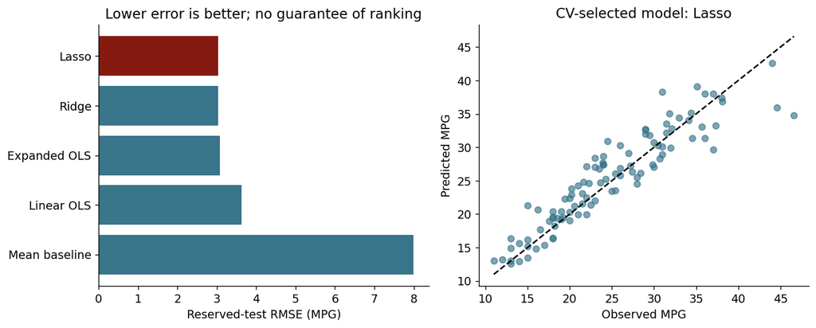

**How to read:** points on the diagonal are perfect predictions; vertical distance from the diagonal is prediction error.

# Lasso coefficients describe a prediction system

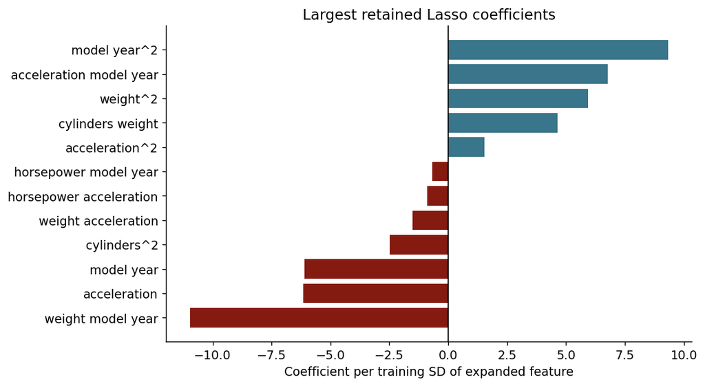

The model created squares and interactions, then rescaled them. A large bar means the feature contributes to this prediction formula; it does not rank scientific importance or establish a cause.

# Optional: logging MPG changes the meaning of coefficients

Taking the logarithm of MPG changes the question from an MPG difference to an approximate percentage difference.

**Simple interpretation for a small coefficient:** a one-unit increase in X is associated with roughly **100 × b percent** change in fitted MPG, holding other included variables fixed.

For larger changes, software should calculate the exact percentage using the exponential transformation.

Use a log outcome only when a percentage interpretation fits the research question. Do not choose it simply because it looks more technical.

# Optional: an interaction allows the slope to change

The model allows the weight-MPG association to differ by model year.

| Model year | Fitted MPG difference for 1,000 lb greater weight |
|---|---:|
| 1972 | -3.84 MPG |
| 1976 | -5.65 MPG |
| 1980 | -7.47 MPG |

**Interaction:** the association of one variable depends on another variable. Interpret the combined slope at meaningful values, not one coefficient by itself.

# Optional: Elastic Net blends Ridge and Lasso

Elastic Net combines the two regularization ideas:

- Ridge-style shrinkage can stabilize groups of related predictors.
- Lasso-style shrinkage can set some coefficients to zero.

Training cross-validation chooses both the overall penalty strength and the balance between the two styles.

Elastic Net is another prediction option, not evidence that selected variables are causal.

# The word “robust” can mean different things

| Term | Plain-language meaning |
|---|---|
| HC3 robust standard errors | Keep the OLS estimates but report uncertainty that better handles uneven residual spread |
| Huber robust regression | Fit the line while reducing the effect of very large residuals |
| Robustness or sensitivity check | Change one reasonable analysis choice and see whether the conclusion changes |

Always name the specific problem being addressed. “Robust” never means that every research problem has been solved.

# The outcome type guides the model choice

| Outcome | Possible starting model |
|---|---|
| Yes/no event | Logistic regression |
| Number of events | A count model such as Poisson regression |
| Typical or median outcome | Quantile regression |
| Repeated observations of countries or firms | A model that accounts for repeated records and dependence |

These are starting points, not automatic choices. Students should justify the model using the outcome, research design, and claim.

# Tools for the research workflow

| Task | Software used here |
|---|---|
| Inspect, document, join data | pandas |
| OLS, formulas, HC3, influence | statsmodels |
| Scaling, CV, Ridge and Lasso | scikit-learn |
| Plots | matplotlib |
| Run and save the analysis | JupyterLab or Google Colab |

R alternatives include `lm`, `sandwich` and `glmnet`.

Software organizes calculations, but the researcher must still justify variables, transformations, assumptions, and claims.

# A results paragraph connects methods to claims

“Using 294 complete training records from the historical Auto MPG data, I estimated an OLS model of MPG on weight, horsepower, model year and origin. A 1,000 lb weight difference was associated with **5.61 fewer MPG** (approximate 95% HC3 interval: **4.65 to 6.57 fewer**). The estimate describes an adjusted association. Unrecorded design differences and possible dependence among related models limit causal interpretation.”

The paragraph moves from sample and specification to estimate and uncertainty, then ends with the claim boundary and limitation.

# Reporting checklist

- Research question, unit of observation and sample flow

- Outcome and predictor definitions with units

- Specification and why it fits the literature

- Estimates and uncertainty, or a validation design and errors

- Diagnostic findings and documented robustness checks

- Limits to generalization and causal interpretation

- Data source, code, versions, references and AI-use disclosure

A reader should be able to trace every reported claim back to a defined sample, variable, model, diagnostic, and source.

# Data and technical references

**Data:** Quinlan, R. (1993). *Auto MPG*. UCI Machine Learning Repository. [doi.org/10.24432/C5859H](https://doi.org/10.24432/C5859H). CC BY 4.0.

**Units:** [ISLR2 authors’ Auto documentation](https://search.r-project.org/CRAN/refmans/ISLR2/html/Auto.html).

**OLS and diagnostics:** [statsmodels HC3](https://www.statsmodels.org/stable/generated/statsmodels.regression.linear_model.OLSResults.HC3_se.html) and [regression diagnostics](https://www.statsmodels.org/stable/examples/notebooks/generated/regression_diagnostics.html).

**Prediction:** scikit-learn [linear models](https://scikit-learn.org/stable/modules/linear_model.html) and [data leakage guidance](https://scikit-learn.org/stable/common_pitfalls.html).

Primary data and software documentation make the analysis auditable and help distinguish source facts from the researcher's modelling choices.